# INSY 5378 Data Science Final Project

## Topic Modelling

One of the effective unsupervised methods for uncovering hidden topics from the given batch of documents in NLP is topic modeling. Topic modeling has significantly improved recent research, particularly in text categorization issues. Identifying hidden topics in text might benefit ML models in classifying data. There are other topic modeling methods that can be explored, however this thesis primarily focuses on "Latent Dirichlet Allocation (LDA)," one of the well-liked topic modeling approaches. It uses the Dirichlet probability distribution and an unsupervised machine learning technique to determine the likelihood of each hidden topics (No. of hidden topics are based on users).

```python
corpus = list(df['content'])
cleaned_corpus = [cleaning_data(txt) for txt in corpus]
```

```python
from sklearn.decomposition import NMF, LatentDirichletAllocation, TruncatedSVD
from sklearn.feature_extraction.text import CountVectorizer
```

LDA : It builds a topic per document model and words per topic model, modeled as Dirichlet distributions. The end goal of LDA is to find the most optimal representation of the Document-Topic matrix and the Topic-Word matrix to find the most optimized Document-Topic distribution and Topic-Word distribution.

As LDA assumes that documents are a mixture of topics and topics are a mixture of words so LDA backtracks from the document level to identify which topics would have generated these documents and which words would have generated those topics.

```python
vectorizer = CountVectorizer(min_df=10, max_df=0.9,
                             stop_words='english', lowercase=True)
data_vectorized = vectorizer.fit_transform(cleaned_corpus)
```

```python
#function to get topics and put them in dataframe columns - we pass an empty dataframe to it
def get_topics(model, vectorizer, model_name, df, top_n = 20):
        result = []
        for idx, topic in enumerate(model.components_):
            #print("Topic %d:" % (idx))
            topic_label = model_name + "_topic_" + str(idx)
            score = "SCORE_" + str(idx)
            aList = [(vectorizer.get_feature_names()[i], topic[i])
                            for i in topic.argsort()[:-top_n - 1:-1]]
            l1, l2 = zip(*aList)
            df[topic_label] = l1
            df[score] = l2
```

```python
#Selecting top 20 topics
n = 20
```

```python
print("Working on " + str(n) + " topics .....")
df = pd.DataFrame()
# Build a Latent Dirichlet Allocation Model
print("LDA being performed ...")
lda_model = LatentDirichletAllocation(n_components=n, max_iter=5, learning_method='online')
doc_topics = lda_model.fit_transform(data_vectorized)
print("Generating LDA Model .....")
get_topics(lda_model, vectorizer, "LDA", df) #populates the dataframe
#display the first 10 records of the dataframe
df.head(10)
```

```
Working on 20 topics .....
LDA being performed ...
Generating LDA Model .....
```

|  | LDA_topic_0 | SCORE_0 | LDA_topic_1 | SCORE_1 | LDA_topic_2 | SCORE_2 | LDA_topic_3 | SCORE_3 | LDA_topic_4 | SCORE_4 | ... | LDA_topic_15 | SCORE_15 | LDA_topic_16 | SCORE_16 | LDA_topic_17 | SCORE_17 | LDA_topic_18 | SCORE_18 | LDA_topic_19 | SCORE_19 |
| --- | --- | --- | --- | --- | --- | --- | --- | --- | --- | --- | --- | --- | --- | --- | --- | --- | --- | --- | --- | --- | --- |
| 0 | food | 3071.349994 | election | 6802.224590 | company | 6414.695389 | people | 14431.904599 | la | 4701.831086 | ... | said | 16036.130083 | dr | 4449.019967 | obama | 2226.604483 | clinton | 13618.959753 | police | 9965.144533 |
| 1 | water | 3069.789774 | vote | 4336.588193 | million | 4609.951526 | like | 10547.720429 | el | 3113.039517 | ... | family | 2995.235531 | health | 3339.860586 | 2017 | 2126.669575 | hillary | 6884.852566 | people | 4507.321969 |
| 2 | like | 1028.821017 | voters | 3669.258165 | companies | 3350.012703 | time | 7454.001418 | en | 2863.958752 | ... | school | 2902.770343 | medical | 2188.244591 | gun | 1628.743053 | fbi | 5858.684292 | officers | 3081.856508 |
| 3 | body | 963.361822 | 2016 | 3582.885544 | new | 2839.917794 | world | 7212.444936 | que | 2501.228151 | ... | day | 2873.305409 | study | 2106.722770 | twitter | 1523.117495 | investigation | 4703.283668 | said | 2646.039243 |
| 4 | eat | 863.772697 | clinton | 2921.233848 | said | 2571.480341 | know | 6961.789743 | le | 1443.767441 | ... | home | 2767.768178 | cancer | 1784.399391 | breitbart | 1442.100729 | emails | 4279.512145 | man | 2137.592029 |
| 5 | make | 860.658631 | voting | 2781.601404 | 000 | 2399.075024 | think | 6620.886294 | los | 1397.718265 | ... | time | 2747.933446 | drug | 1628.920759 | new | 917.112295 | comey | 3848.726223 | killed | 1973.726524 |
| 6 | use | 806.532547 | percent | 2518.795532 | money | 2393.446915 | way | 6378.945961 | der | 1206.179290 | ... | team | 2712.169818 | research | 1482.615762 | news | 706.753678 | email | 3822.474315 | law | 1775.606711 |
| 7 | plant | 778.570291 | state | 2427.929430 | business | 2379.765719 | going | 4982.581467 | se | 1117.654046 | ... | told | 2591.390665 | children | 1327.298178 | follow | 679.649029 | information | 3158.222461 | officer | 1741.392468 |
| 8 | foods | 774.814136 | hillary | 2418.284310 | year | 1950.048558 | make | 4934.146627 | die | 1094.561610 | ... | years | 2377.994435 | patients | 1324.548310 | white | 667.548251 | campaign | 2570.990743 | video | 1720.260366 |
| 9 | help | 754.535683 | states | 1992.248056 | billion | 1877.117436 | right | 4715.547321 | del | 1093.469405 | ... | game | 2284.624212 | doctors | 1261.017997 | house | 609.845572 | department | 2435.418745 | arrested | 1710.477368 |

10 rows × 40 columns

```python
#Let us try non-negative matrix factorization
nmf_df = pd.DataFrame()
print("NMF being performed ....")
# Build a Non-Negative Matrix Factorization Model
nmf_model = NMF(n_components=n, max_iter=5)
nmf_Z = nmf_model.fit_transform(data_vectorized)

print("Generating NMF Model ....")
get_topics(nmf_model, vectorizer, "NMF", nmf_df)
nmf_df.head()
```

```
NMF being performed ....
```

```
Generating NMF Model ....
```

|  | NMF_topic_0 | SCORE_0 | NMF_topic_1 | SCORE_1 | NMF_topic_2 | SCORE_2 | NMF_topic_3 | SCORE_3 | NMF_topic_4 | SCORE_4 | ... | NMF_topic_15 | SCORE_15 | NMF_topic_16 | SCORE_16 | NMF_topic_17 | SCORE_17 | NMF_topic_18 | SCORE_18 | NMF_topic_19 | SCORE_19 |
| --- | --- | --- | --- | --- | --- | --- | --- | --- | --- | --- | --- | --- | --- | --- | --- | --- | --- | --- | --- | --- | --- |
| 0 | mr | 52.561093 | people | 15.009161 | trump | 32.551369 | clinton | 25.001316 | said | 29.090750 | ... | health | 9.441275 | ms | 22.732258 | party | 10.544996 | court | 11.455821 | russia | 19.748413 |
| 1 | said | 12.658672 | like | 8.450305 | donald | 4.798190 | hillary | 9.832171 | people | 2.373026 | ... | care | 6.324316 | women | 2.457551 | political | 7.923615 | law | 6.038791 | russian | 11.696778 |
| 2 | trump | 3.329297 | know | 6.281021 | president | 4.213202 | mrs | 4.259926 | like | 2.110036 | ... | house | 5.707195 | family | 1.718971 | election | 7.651490 | judge | 6.021589 | putin | 6.687180 |
| 3 | new | 2.842578 | going | 6.071166 | campaign | 2.357802 | campaign | 4.101875 | told | 1.662685 | ... | republicans | 5.169212 | mr | 1.374130 | media | 6.910606 | justice | 5.120857 | nato | 2.606004 |
| 4 | york | 2.333138 | think | 5.747065 | election | 1.968968 | emails | 3.015767 | years | 1.581895 | ... | republican | 4.664551 | mother | 1.194493 | people | 5.726502 | school | 4.748186 | moscow | 2.478713 |

5 rows × 40 columns

```python
nmf_model.components_.shape, nmf_Z.shape
# Since its a factorization technique, it takes a matrix and returns 2 matrices.
#first matrix is the model we intitiated i.e. 20 topics and 32261 words
# second matrix gives all the document and is called document topic matrix i.e. it gives
#(20800 in our dataset) and 20 topics
```

```
((20, 32261), (20800, 20))
```

This transformer performs linear dimensionality reduction by means of truncated singular value decomposition (SVD). Contrary to PCA, this estimator does not center the data before computing the singular value decomposition. This means it can work with sparse matrices efficiently.

In particular, truncated SVD works on term count/tf-idf matrices as returned by the vectorizers in sklearn.feature_extraction.text. In that context, it is known as latent semantic analysis (LSA).

```python
lsi_df = pd.DataFrame()
print("LSI being performed ...")
# Build a Latent Semantic Indexing Model
lsi_model = TruncatedSVD(n_components=n, n_iter = 5)
lsi_Z = lsi_model.fit_transform(data_vectorized)

print("Generating LSI Model .....")
get_topics(lsi_model, vectorizer, "LSI", lsi_df)
lsi_df.head()
```

```
LSI being performed ...
Generating LSI Model .....
```

|  | LSI_topic_0 | SCORE_0 | LSI_topic_1 | SCORE_1 | LSI_topic_2 | SCORE_2 | LSI_topic_3 | SCORE_3 | LSI_topic_4 | SCORE_4 | ... | LSI_topic_15 | SCORE_15 | LSI_topic_16 | SCORE_16 | LSI_topic_17 | SCORE_17 | LSI_topic_18 | SCORE_18 | LSI_topic_19 | SCORE_19 |
| --- | --- | --- | --- | --- | --- | --- | --- | --- | --- | --- | --- | --- | --- | --- | --- | --- | --- | --- | --- | --- | --- |
| 0 | mr | 0.464762 | people | 0.254587 | trump | 0.704583 | trump | 0.396565 | mr | 0.377163 | ... | police | 0.286693 | ms | 0.681846 | syria | 0.162251 | russia | 0.223903 | russia | 0.283843 |
| 1 | said | 0.389130 | like | 0.150918 | clinton | 0.259198 | people | 0.175979 | obama | 0.253502 | ... | money | 0.166082 | state | 0.226355 | children | 0.157163 | court | 0.193836 | school | 0.212236 |
| 2 | trump | 0.348215 | world | 0.111059 | hillary | 0.151022 | going | 0.112903 | government | 0.142461 | ... | trump | 0.163292 | california | 0.179024 | school | 0.135226 | school | 0.180324 | people | 0.180507 |
| 3 | people | 0.180868 | government | 0.104184 | donald | 0.122339 | like | 0.103107 | war | 0.136485 | ... | water | 0.152698 | president | 0.111633 | united | 0.124623 | black | 0.159828 | russian | 0.174320 |
| 4 | new | 0.157584 | time | 0.100444 | president | 0.117682 | think | 0.092070 | world | 0.114945 | ... | obama | 0.149950 | court | 0.107385 | health | 0.123787 | russian | 0.115885 | black | 0.165971 |

5 rows × 40 columns

```python
#Let us take a look at our cleaned corpus
cleaned_corpus[:2]
```

```
['darrell lucus house dem aide even see comey letter jason chaffetz tweeted house dem aide even see comey letter jason chaffetz tweeted darrell lucus october 30 2016 subscribe jason chaffetz stump american fork utah image courtesy michael jolley available creative commons license apologies keith olb…
 'daniel j flynn flynn hillary clinton big woman campus breitbart ever get feeling life circles roundabout rather heads straight line toward intended destination hillary clinton remains big woman campus leafy liberal wellesley massachusetts everywhere else votes likely inauguration dress remainder d…
```

```python
#let us convert it to a list of a list of words
cleaned_corpus = [txt.split() for txt in cleaned_corpus]
cleaned_corpus[:2]
```

[output not shown]

[output cut: 785 more lines]

[output not shown]

```python
pip install gensim
```

```python
# Remove rare and common tokens.
from gensim.corpora import Dictionary

# Create a dictionary representation of the documents.
dictionary = Dictionary(cleaned_corpus)

# Filter out words that occur less than 10 documents, or more than 80% of the documents.
dictionary.filter_extremes(no_below=10, no_above=0.8)
```

```python
# Bag-of-words representation of the documents.
corpus = [dictionary.doc2bow(doc) for doc in cleaned_corpus]
```

```python
# Train LDA model.
from gensim.models import LdaModel

# Set training parameters.
num_topics = 20
chunksize = 10
passes = 10
iterations = 4
eval_every = None  # Don't evaluate model perplexity, takes too much time.

# Make a index to word dictionary.
temp = dictionary[0]  # This is only to "load" the dictionary.
id2word = dictionary.id2token

model = LdaModel(
    corpus=corpus,
    id2word=id2word,
    chunksize=chunksize,
    alpha='auto',
    eta='auto',
    iterations=iterations,
    num_topics=num_topics,
    passes=passes,
    eval_every=eval_every
)
```

```python
top_topics = model.top_topics(corpus) #, num_words=20)

# Average topic coherence is the sum of topic coherences of all topics, divided by the number of topics.
avg_topic_coherence = sum([t[1] for t in top_topics]) / num_topics
print('Average topic coherence: %.4f.' % avg_topic_coherence)

print(top_topics)
```

```
Average topic coherence: -1.3464.
[([(0.042996705, 'people'), (0.027779032, 'going'), (0.027777236, 'get'), (0.027244892, 'like'), (0.026463168, 'know'), (0.025192045, 'think'), (0.02279994, 'want'), (0.019247908, 'say'), (0.017552124, 'go'), (0.016999863, 'see'), (0.01618469, 'good'), (0.015541019, 'really'), (0.015311696, 'make'),…
```

```python
for i in range(20):
    print("Topic: " + str(i + 1) + ":")
    a, b = zip(*top_topics[i][0])
    for w in b:
        print(w, end=', ')
    print("\n")
```

```
Topic: 1:
people, going, get, like, know, think, want, say, go, see, good, really, make, right, need, things, look, back, something, way,

Topic: 2:
would, could, take, first, change, already, two, next, years, time, since, last, may, still, end, move, far, also, major, likely,

Topic: 3:
one, even, many, like, much, way, yet, long, also, time, part, every, another, different, well, often, others, might, almost, place,

Topic: 4:
mr, said, york, new, times, would, chief, called, j, friday, former, also, thursday, saying, whether, say, last, asked, campaign, week,

Topic: 5:
new, times, york, show, women, first, team, last, best, night, year, like, play, star, also, two, win, set, week, time,

Topic: 6:
man, years, home, day, children, told, one, life, two, later, men, young, back, went, old, time, mother, room, took, first,

Topic: 7:
trump, election, donald, campaign, party, republican, vote, democrats, voters, democratic, presidential, candidate, president, voting, political, win, republicans, supporters, candidates, votes,

Topic: 8:
states, united, u, american, state, security, foreign, international, country, policy, government, countries, north, national, nations, council, agreement, south, also, order,

Topic: 9:
said, city, people, group, two, attack, last, center, killed, according, state, members, officials, three, sunday, local, one, least, area, attacks,

Topic: 10:
percent, money, companies, business, pay, million, tax, financial, jobs, economy, year, economic, market, new, workers, cost, price, bank, work, government,

Topic: 11:
us, world, people, political, america, israel, power, country, war, american, government, history, anti, human, society, nation, americans, must, today, right,

Topic: 12:
clinton, hillary, fbi, campaign, comey, emails, email, investigation, election, weiner, bill, state, presidential, democratic, james, server, private, director, anthony, information,

Topic: 13:
president, obama, house, white, administration, bill, congress, senate, immigration, washington, republicans, bush, office, act, secretary, republican, law, executive, policy, w,

Topic: 14:
1, 2, 000, 5, 3, 10, 4, 6, million, 2015, 11, 7, 8, 9, year, 2016, 30, 15, 25, 16,

Topic: 15:
case, former, c, general, officials, f, director, intelligence, agency, government, public, b, office, investigation, committee, information, chief, r, national, federal,

Topic: 16:
russia, syria, military, war, russian, syrian, al, iran, putin, iraq, forces, islamic, us, saudi, government, nuclear, weapons, western, east, soldiers,

Topic: 17:
news, 2016, twitter, breitbart, post, video, com, follow, october, facebook, reported, daily, november, article, told, story, also, report, march, according,

Topic: 18:
use, also, may, system, help, new, found, research, report, human, data, information, number, based, need, study, university, published, le, list,

Topic: 19:
police, law, black, state, school, rights, officers, officer, federal, students, enforcement, prison, university, public, civil, community, schools, student, illegal, college,

Topic: 20:
health, care, union, european, insurance, british, europe, prime, minister, britain, french, london, france, healthcare, affordable, paris, parliament, may, academic, leader,
```

## Word Cloud

Word Cloud is a data visualization technique used for representing text data in which the size of each word indicates its frequency or importance

```python
news_dataset['text']
```

```
0        house dem aide even see comey letter jason cha...
1        ever get feeling life circles roundabout rathe...
2        truth might get fired october 29 2016 tension ...
3        videos 15 civilians killed single us airstrike...
4        print iranian woman sentenced six years prison...
                               ...
20795    rapper unloaded black celebrities met donald t...
20796    green bay packers lost washington redskins wee...
20797    macy today grew union several great names amer...
20798    nato russia hold parallel exercises balkans 11...
20799    david swanson author activist journalist radio...
Name: text, Length: 20800, dtype: object
```

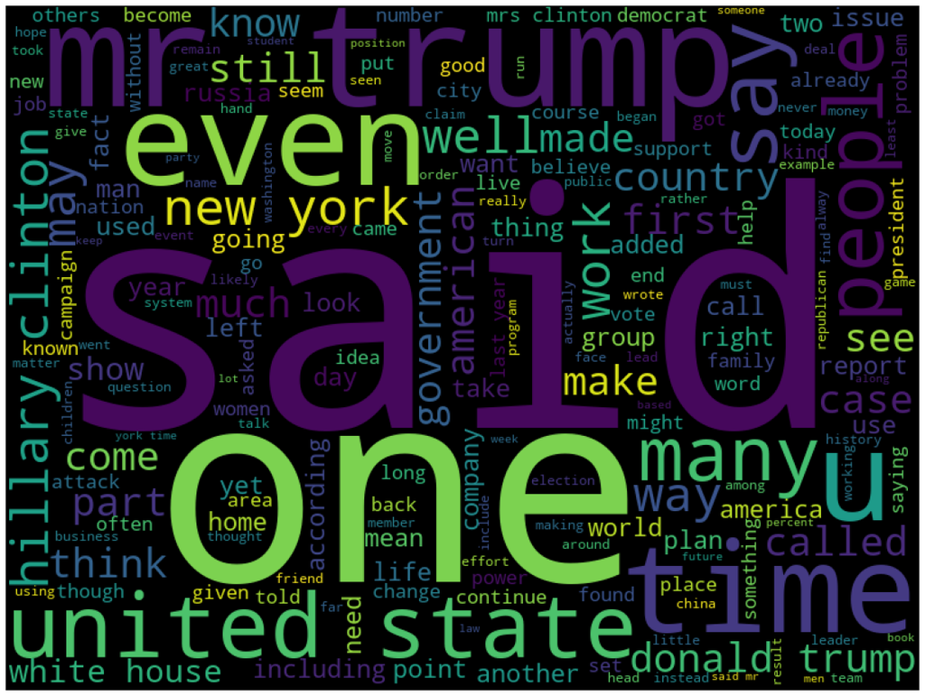

```python
from wordcloud import WordCloud, ImageColorGenerator
# initialize the word cloud
wordcloud = WordCloud(background_color='black', width=800, height=600)
# generate the word cloud
text_cloud = wordcloud.generate(" ".join(news_dataset['text']))
# plotting the word cloud
plt.figure(figsize=(20,30))
plt.imshow(text_cloud)
plt.axis('off')
plt.show()
```

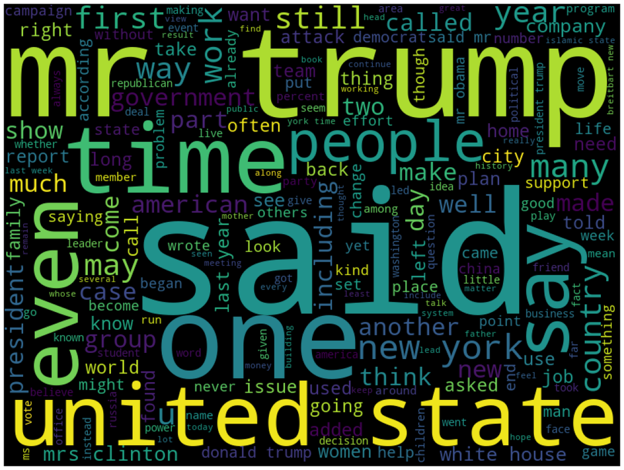

```python
# reliable news (0) # Real news
reliable_news = " ".join(news_dataset[news_dataset['label']==0]['text'])
wc = wordcloud.generate(reliable_news)
plt.figure(figsize=(20,30))
plt.imshow(wc)
plt.axis('off')
plt.show()
```

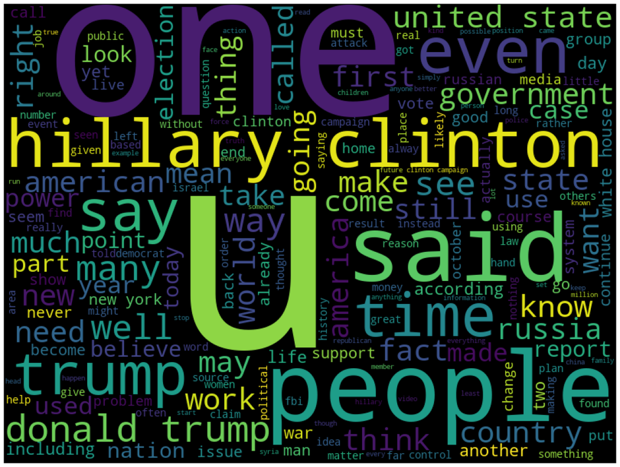

```python
# unreliable news (1) # Fake news
unreliable_news = " ".join(news_dataset[news_dataset['label']==1]['text'])
wc = wordcloud.generate(unreliable_news)
plt.figure(figsize=(20,30))
plt.imshow(wc)
plt.axis('off')
plt.show()
```

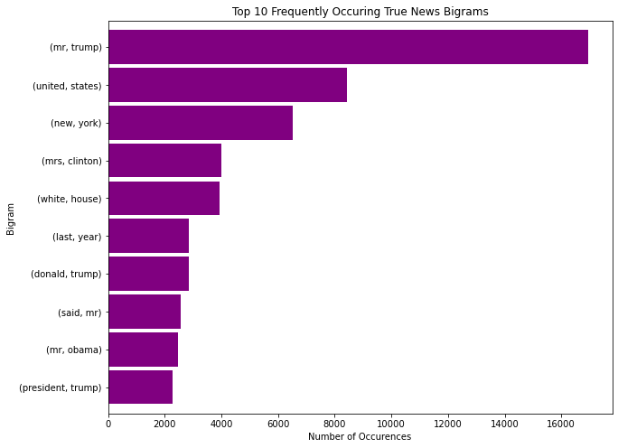

```python
# Bigram

def plot_top_ngrams(corpus, title, ylabel, xlabel="Number of Occurences", n =2):
    true_bigram = (pd.Series(nltk.ngrams(corpus.split(), n)).value_counts())[:10]
    true_bigram.sort_values().plot.barh(color='purple', width=.9, figsize=(10,8))
    plt.title(title)
    plt.ylabel(ylabel)
    plt.xlabel(xlabel)
    plt.show()


plot_top_ngrams(reliable_news, "Top 10 Frequently Occuring True News Bigrams", "Bigram", n=2)
```

References : https://scikit-learn.org/stable/modules/generated/sklearn.feature_extraction.text.CountVectorizer.html https://scikit-learn.org/stable/modules/generated/sklearn.decomposition.LatentDirichletAllocation.html https://towardsdatascience.com/nlp-extracting-the-main-topics-from-your-dataset-using-lda-in-minutes-21486f5aa925

Thank you